# Proyecto final

# Convertir a phyloseq

En esta parte se convierten los objetos que creamos en phyloseq, van a tener diferente información de utilidad en diferentes procesos.

```r
#esto simplemente es para el formato de los plots que van a crearse más adelante
theme_set(theme_bw())
```

Construir un *data frame* a partir de la información que hay en los archivos.

```r
ll<-read.table("Oredered_accessions.txt")#archivo con los nombres de los accesos ordenados de cada muestra
samples.out <- ll[[1]] #nombres de los archivos filtrados y unidos en orden
#todo lo de abajo es para armar el dataframe con el que nuestro objeto de phyloseq va a basarse
suelo<-paste0(c(rep("LC",32),rep("LF",32),rep("LG",32),rep("SC",32),rep("SF",32),rep("SG",32), rep("neg",2)))
replica<-as.character(paste0(c(rep(paste0(c(rep(1,4),rep(2,4),rep(3,4),rep(4,4))),12),rep("neg",2))))
humedad<-paste0(c(rep(c(15,30,60,90),48),rep("neg",2)))
samdf<-data.frame(Suelo=suelo,Humedad=humedad)
samdf$Replica<-replica
rownames(samdf) <- samples.out#just renames to the file names
```

En este paso construimos nuesto objeto phyloseq con los datos que nos interesan.

```r
ps <- phyloseq(otu_table(seqtab.nochim, taxa_are_rows=FALSE), #genera nuestro objeto phyloseq usando los datos que le damos a la tabla
               sample_data(samdf),
               tax_table(taxa))
rr<-c("SRR9700969", "SRR9700912")
ps <- prune_samples(sample_names(ps) != rr, ps) # Remover los controles negativos
```

```r
dna <- Biostrings::DNAStringSet(taxa_names(ps))#toma las secuencias como los nombres de la taxa, luego toma esas secuencias para generarlos como dns strings
names(dna) <- taxa_names(ps)#los nombres de las secuencias
ps <- merge_phyloseq(ps, dna)#une los objetos creados de phyloseq con las secuencias i
taxa_names(ps) <- paste0("ASV", seq(ntaxa(ps)))#asigna ASV y numera nada más, esos son los nombres ahora
ps
```

```
## phyloseq-class experiment-level object
## otu_table()   OTU Table:         [ 10525 taxa and 192 samples ]
## sample_data() Sample Data:       [ 192 samples by 3 sample variables ]
## tax_table()   Taxonomy Table:    [ 10525 taxa by 7 taxonomic ranks ]
## refseq()      DNAStringSet:      [ 10525 reference sequences ]
```

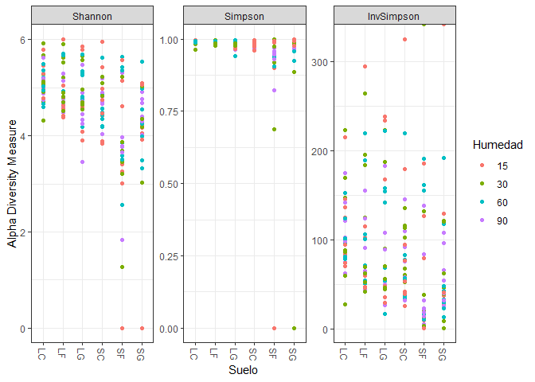

```r
plot_richness(ps, x="Suelo", measures = c("Shannon","Simpson","InvSimpson"), color = "Humedad")
```

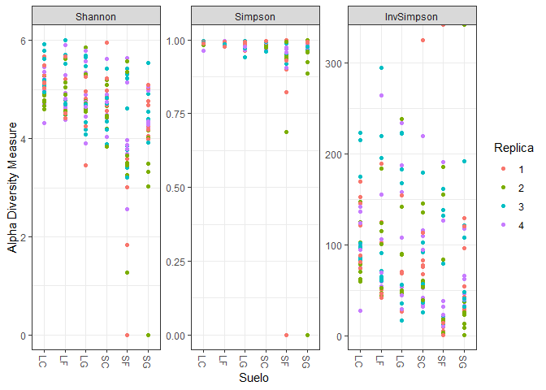

```r
plot_richness(ps, x="Suelo", measures = c("Shannon","Simpson","InvSimpson"), color = "Replica")
```

# Gráficos de barras apiladas de abundancias

En esta parte graficamos las abundancias de las bacterias en las muestras, pero no es de mucha utilidad.

[figure not shown]

```r
top20 <- names(sort(taxa_sums(ps), decreasing=TRUE))[1:194]
ps.top20 <- transform_sample_counts(ps, function(OTU) OTU/sum(OTU))
ps.top20 <- prune_taxa(top20, ps.top20)
plot_bar(ps.top20, x="Suelo", fill="Family") + facet_wrap(~Humedad, scales="free_x")
```

# Parte con hongos

Pese a que la metodología usada para determinar organismos como hongos en el artículo estaba mal, aquí hay una variante de lo hehco anterior pero con la base de datos de referencia en el archivo RDP_LSU_fixed_train_set_v2.fa.gz . Para saber cómo se obtuvo, ver script de shell en Github.

```r
#esta función empieza con la asignación de la taxonomía a las secuencias dado el amplicon usado, igual usa una serie de secuencias de entrenamiento con taxonomía conocida para asignar correctamente las muestras usadas
#taxa2 <- assignTaxonomy(seqtab.nochim,"~/R/Genomica_funcional/pro_fin_genfun/tax/RDP_LSU_fixed_train_set_v2.fa.gz", multithread=T)
#para agilizar el proceso, se corrió el objeto y se guardó para posteiormente solo cargarse
#save(taxa2,file="~/R/Genomica_funcional/pro_fin_genfun/taxa3.RData")
load("taxa3.RData")
```

```r
#esta parte es para asignar las especies a cada secuencia, pero se requiere cumplir con ciertos criterios para que pueda asignarse, para ver los parámetros que se deben de cumplir hay que checar la dacumentación
#taxa2 <- addSpecies(taxa,"~/R/Genomica_funcional/pro_fin_genfun/tax/rdp_species_assignment_LSU_v2.fa.gz")
#mismo proceso que el objeto anterior
#save(taxa2,file="~/R/Genomica_funcional/pro_fin_genfun/taxa2.RData")
load("taxa2.RData")
```

Para poder visualiar más concretamente la taxonomía que se ha asignado, se puede hacer lo siguiente.

```r
taxa.print2 <- taxa2 # asignamos nuestro taxa a un objeto llamado taxa.print para modificar
rownames(taxa.print2) <- NULL #los nombres de los renglones eran las secuencias enteras, entonces se remueven
head(taxa.print2,15)#now it says the taxonomy rather than the full sequence and the taxonomy
```

```
##       Kingdom     Phylum            Class       Order          Family
##  [1,] NA          NA                NA          NA             NA
##  [2,] "Eukaryota" NA                NA          NA             NA
##  [3,] "Eukaryota" NA                NA          NA             NA
##  [4,] "Eukaryota" NA                NA          NA             NA
##  [5,] "Eukaryota" NA                NA          NA             NA
##  [6,] "Eukaryota" NA                NA          NA             NA
##  [7,] "Eukaryota" NA                NA          NA             NA
##  [8,] "Eukaryota" NA                NA          NA             NA
##  [9,] NA          NA                NA          NA             NA
## [10,] "Eukaryota" NA                NA          NA             NA
## [11,] NA          NA                NA          NA             NA
## [12,] "Eukaryota" NA                NA          NA             NA
## [13,] "Eukaryota" NA                NA          NA             NA
## [14,] "Eukaryota" NA                NA          NA             NA
```

[output cut: 17 more lines]

## Convertir a phyloseq

En esta parte se convierten los objetos que creamos en phyloseq, van a tener diferente información de utilidad en diferentes procesos.

```r
#esto simplemente es para el formato de los plots que van a crearse más adelante
theme_set(theme_bw())
#usaremos el data fram samdf de las bacterias
```

En este paso construimos nuesto objeto phyloseq con los datos que nos interesan.

```r
ps2 <- phyloseq(otu_table(seqtab.nochim, taxa_are_rows=FALSE), #genera nuestro objeto phyloseq usando los datos que le damos a la tabla
               sample_data(samdf),
               tax_table(taxa2))
rr<-c("SRR9700969", "SRR9700912")
ps2 <- prune_samples(sample_names(ps2) != rr, ps2) # Remover los controles negativos
```

```r
dna2 <- Biostrings::DNAStringSet(taxa_names(ps2))#toma las secuencias como los nombres de la taxa, luego toma esas secuencias para generarlos como dns strings
names(dna2) <- taxa_names(ps2)#los nombres de las secuencias
ps2 <- merge_phyloseq(ps2, dna2)#une los objetos creados de phyloseq con las secuencias i
taxa_names(ps2) <- paste0("ASV", seq(ntaxa(ps2)))#asigna ASV y numera nada más, esos son los nombres ahora
ps2
```

```
## phyloseq-class experiment-level object
## otu_table()   OTU Table:         [ 10525 taxa and 192 samples ]
## sample_data() Sample Data:       [ 192 samples by 3 sample variables ]
## tax_table()   Taxonomy Table:    [ 10525 taxa by 8 taxonomic ranks ]
## refseq()      DNAStringSet:      [ 10525 reference sequences ]
```

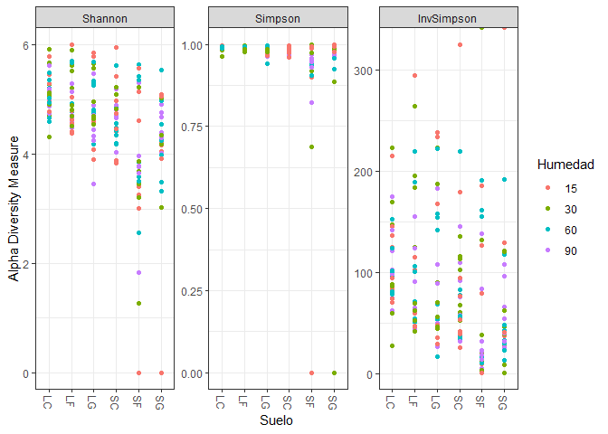

```r
plot_richness(ps2, x="Suelo", measures = c("Shannon","Simpson","InvSimpson"), color = "Humedad")
```

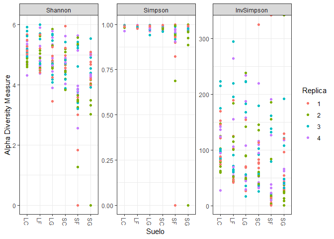

```r
plot_richness(ps2, x="Suelo", measures = c("Shannon","Simpson","InvSimpson"), color = "Replica")
```

## Gráficos de barras apiladas de abundancias

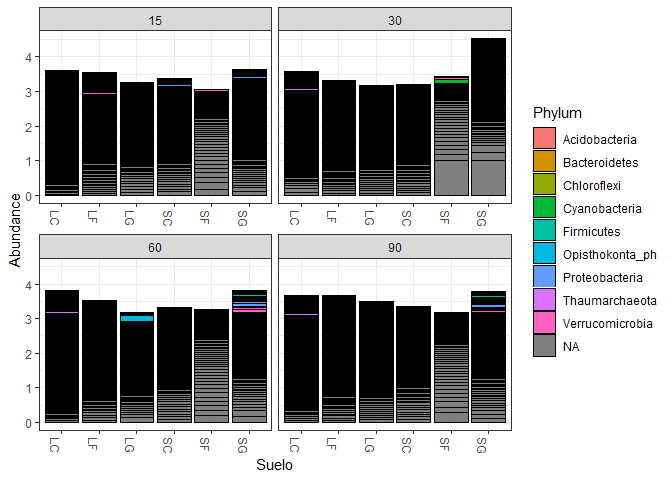

```r
top20.2 <- names(sort(taxa_sums(ps2), decreasing=TRUE))[1:194]
ps.top20.2 <- transform_sample_counts(ps2, function(OTU) OTU/sum(OTU))
ps.top20.2 <- prune_taxa(top20.2, ps.top20.2)
plot_bar(ps.top20.2, x="Suelo", fill="Phylum") + facet_wrap(~Humedad, scales="free_x")
```

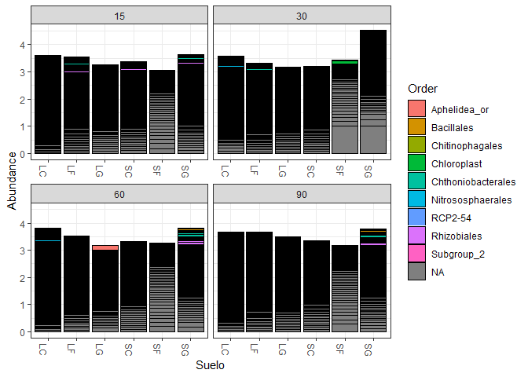

```r
plot_bar(ps.top20.2, x="Suelo", fill="Order") + facet_wrap(~Humedad, scales="free_x")
```

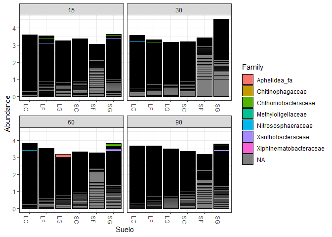

```r
plot_bar(ps.top20.2, x="Suelo", fill="Family") + facet_wrap(~Humedad, scales="free_x")
```

# Notas importantes

En el artículo describen la extracción de muestras específicas de hongos usando la herramienta ITSx; sin embargo, esta no está diesñada para realizar dicho trabajo. Cuando se visitó el manual de esta herramienta, explícitamente mencionan que no se debe de hacer esto, pues no está diseñada para realizar la identificació. Por otro lado, el uso de la base de datos para hongos habida en el manual de la librería **dada2**, no fue lo suficientemente adecuada para dar una buena aproximación para la composición de las muestras, aunque cabe recalcar que los autores del artículo mencionan el uso de **Warcup** para la identificación taxonómica de los hongos. A continuación se muestra la evidencia de los puntos expuestos,

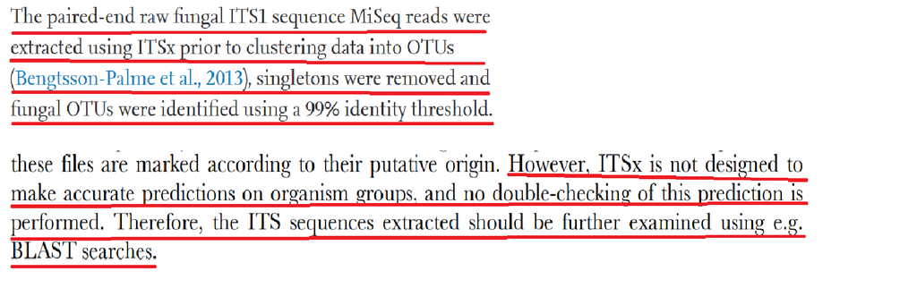

Errores encontrados

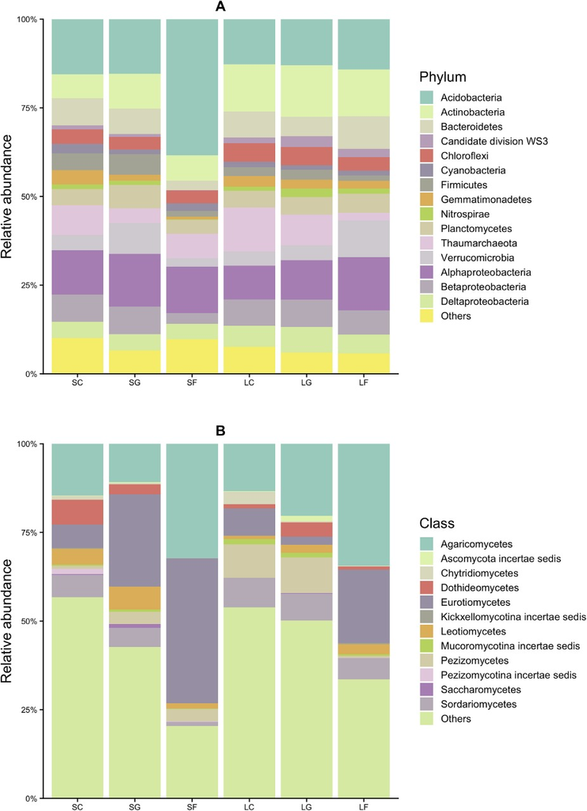

Comunidades del artículo

# Red de Correlación

Se van a cargar los datos de correlación de las variables epidáficas con los phyla encontrados. Los datos se obtuvieron de https://ars.els-cdn.com/content/image/1-s2.0-S0038071719301762-mmc1.xlsx subidos por los autores del artículo. Se trabajó con la tabla 8 que contiene la correlación de Spearman entre las abundancias encontradas tanto de bacterias como de hongos, y las variables epidáficas

```r
tabla <- read.csv("epidaficas_completo.csv", header = T)
tabla
```

```
##           phyla_class                Edaphic.variables qGlucosidase
## 1  Bacterial_archaeal                    Acidobacteria         0.58
## 2  Bacterial_archaeal                   Actinobacteria        -0.35
## 3  Bacterial_archaeal                    Bacteroidetes        -0.11
## 4  Bacterial_archaeal           Candidate division WS3        -0.42
## 5  Bacterial_archaeal                      Chloroflexi        -0.24
## 6  Bacterial_archaeal                    Cyanobacteria         0.01
## 7  Bacterial_archaeal                       Firmicutes         0.10
## 8  Bacterial_archaeal                 Gemmatimonadetes        -0.37
## 9  Bacterial_archaeal                      Nitrospirae        -0.49
## 10 Bacterial_archaeal                   Planctomycetes         0.33
## 11 Bacterial_archaeal                   Thaumarchaeota        -0.40
## 12 Bacterial_archaeal                  Verrucomicrobia         0.20
## 13 Bacterial_archaeal              Alphaproteobacteria         0.36
## 14 Bacterial_archaeal               Betaproteobacteria        -0.19
```

[output cut: 69 more lines]

Se hace un subset de la base de datos para crear ambas redes separadas

```r
# Bacterias
tabla_b <- subset(tabla, tabla$phyla_class == "Bacterial_archaeal")
rownames(tabla_b) <- tabla_b[,2] #Se asginan los nombres de los renglones con los nombres de los phylum encontrados
tabla_b <- tabla_b [,-c(1,2)] #Se eliminan los datos discretos para crear la matriz de correlación
# Hongos
tabla_h <- subset(tabla, tabla$phyla_class == "Fungal_class")
rownames(tabla_h) <- tabla_h[,2] #Se asginan los nombres de los renglones con los nombres de los phylum encontrados
tabla_h <- tabla_h [,-c(1,2)] #Se eliminan los datos discretos para crear la matriz de correlación
```

Se construye la matriz de correlación

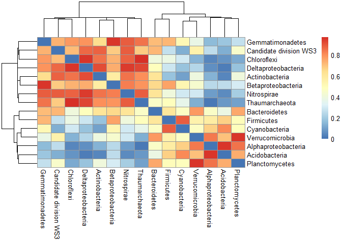

```r
# Bacterias
cepi_b <- cor(t(tabla_b)) # se transpone la matriz para poder tener la correlación entre los phylum y se guarda en un objeto
cepi_b <- as.matrix(cepi_b) # se cambia la clase del objeto a matriz
nepi_b <- (cepi_b + 1)/2 # Se hace la suma de una unidad a cada valor de la matriz y se divide entre dos para tener valores entre 0 y 1.
diag(nepi_b) <- rep(0, length( diag(nepi_b))) # Se cambian todos los valores de la diagonal por cero para evitar autoconexiones entre nodos
pheatmap(nepi_b) # Se puede observar la correlación de la matriz creada con un heatmap
```

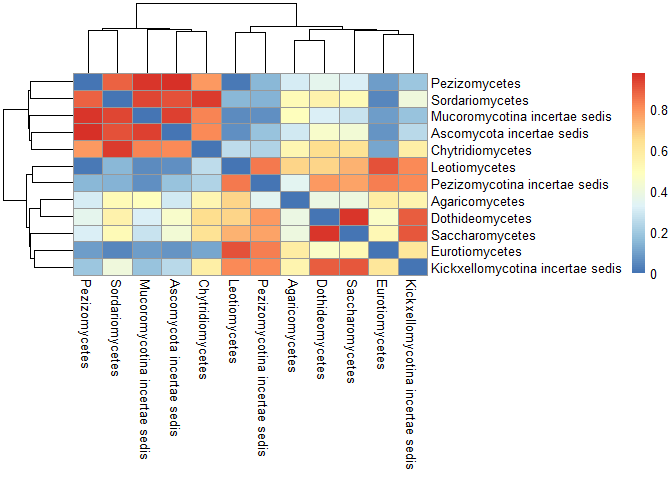

```r
# Hongos
cepi_h <- cor(t(tabla_h)) # se transpone la matriz para poder tener la correlación entre los phylum y se guarda en un objeto
cepi_h <- as.matrix(cepi_h) # se cambia la clase del objeto a matriz
nepi_h <- (cepi_h + 1)/2 # Se hace la suma de una unidad a cada valor de la matriz y se divide entre dos para tener valores entre 0 y 1.
diag(nepi_h) <- rep(0, length( diag(nepi_h))) # Se cambian todos los valores de la diagonal por cero para evitar autoconexiones entre nodos
pheatmap(nepi_h) # Se puede observar la correlación de la matriz creada con un heatmap
```

Se construyen las redes con el paquete igraph, se especifica que no son dirigidas y que son redes pesadas.

```r
# Bacterias
gepi2_b <- graph_from_adjacency_matrix(nepi_b,  mode = "undirected", weighted = T )
is_weighted(gepi2_b) # Se comprueba que la red es pesada usando la función is_weighted. Arroja el valor de TRUE cuando la red es pesada
```

```
## [1] TRUE
```

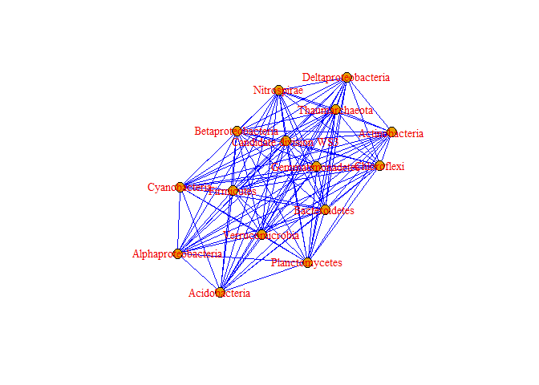

```r
plot(gepi2_b, vertex.size = 10, edge.arrow.size = 0.25,
     edge.arrow.width = 2.5, edge.color = "blue", vertex.label.color ="red2",
     vertex.label.cex = 0.9)
```

```r
# Hongos
gepi2_h <- graph_from_adjacency_matrix(nepi_h,  mode = "undirected",
                                     weighted = T )
is_weighted(gepi2_h) # Se comprueba que la red es pesada usando la función is_weighted. Arroja el valor de TRUE cuando la red es pesada
```

```
## [1] TRUE
```

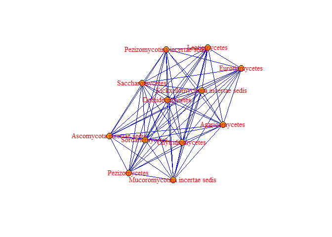

```r
plot(gepi2_h, vertex.size = 10, edge.arrow.size = 0.25,
     edge.arrow.width = 2.5, edge.color = "blue", vertex.label.color ="red2",
     vertex.label.cex = 0.9)
```

Se clusteriza la red por distintos métodos para observar cómo se agrupan los phyla de acuerdo a la correlación que tienen entre estos con base en los factores epidáficos que los afectan.

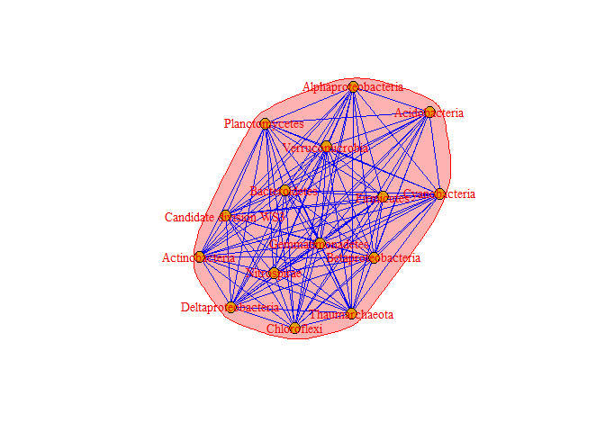

```r
# Bacterias
gepi2c_b1 <- cluster_infomap(gepi2_b) # Método infomap
plot(gepi2c_b1, gepi2_b, vertex.size = 10, edge.arrow.size = 0.25,
     edge.arrow.width = 2.5, edge.color = "blue", vertex.label.color ="red2",
     vertex.label.cex = 0.9)
```